# Assignment 5: Space-Time Prediction of Bike Share Demand

Author

Katie Knox

Published

November 24, 2025

## Part 1: Q4 (October - December) 2024 Data

I have chosen to examine Q4 data from 2024 (last year) as we are currently in Q4 of 2025 as of writing, and I believe last year’s patterns for this time of year would be best to inform predictions for Q4 2025.

```r
plotTheme <- theme(
  plot.title = element_text(size = 14, face = "bold"),
  plot.subtitle = element_text(size = 10),
  plot.caption = element_text(size = 8),
  axis.text.x = element_text(size = 10, angle = 45, hjust = 1),
  axis.text.y = element_text(size = 10),
  axis.title = element_text(size = 11, face = "bold"),
  panel.background = element_blank(),
  panel.grid.major = element_line(colour = "#D0D0D0", size = 0.2),
  panel.grid.minor = element_blank(),
  axis.ticks = element_blank(),
  legend.position = "right"
)

mapTheme <- theme(
  plot.title = element_text(size = 14, face = "bold"),
  plot.subtitle = element_text(size = 10),
  plot.caption = element_text(size = 8),
  axis.line = element_blank(),
  axis.text = element_blank(),
  axis.ticks = element_blank(),
  axis.title = element_blank(),
  panel.background = element_blank(),
  panel.border = element_blank(),
  panel.grid.major = element_line(colour = 'transparent'),
  panel.grid.minor = element_blank(),
  legend.position = "right",
  plot.margin = margin(1, 1, 1, 1, 'cm'),
  legend.key.height = unit(1, "cm"),
  legend.key.width = unit(0.2, "cm")
)

palette5 <- c("#eff3ff", "#bdd7e7", "#6baed6", "#3182bd", "#08519c")
```

```r
# Read Q4 2024 data
indego <- read_csv("../data/indego-trips-2024-q4.csv")

# Quick look at the data
glimpse(indego)
```

```
Rows: 299,121
Columns: 15
$ trip_id             <dbl> 1050296434, 1050293063, 1050296229, 1050276817, 10…
$ duration            <dbl> 22, 8, 12, 1, 5, 9, 5, 6, 16, 16, 16, 39, 6, 40, 1…
$ start_time          <chr> "10/1/2024 0:00", "10/1/2024 0:06", "10/1/2024 0:0…
$ end_time            <chr> "10/1/2024 0:22", "10/1/2024 0:14", "10/1/2024 0:1…
$ start_station       <dbl> 3322, 3166, 3007, 3166, 3075, 3166, 3030, 3010, 33…
$ start_lat           <dbl> 39.93638, 39.97195, 39.94517, 39.97195, 39.96718, …
$ start_lon           <dbl> -75.15526, -75.13445, -75.15993, -75.13445, -75.16…
$ end_station         <dbl> 3375, 3017, 3244, 3166, 3102, 3008, 3203, 3163, 33…
$ end_lat             <dbl> 39.96036, 39.98003, 39.93865, 39.97195, 39.96759, …
$ end_lon             <dbl> -75.14020, -75.14371, -75.16674, -75.13445, -75.17…
$ bike_id             <chr> "03580", "05386", "18082", "02729", "18519", "0272…
$ plan_duration       <dbl> 365, 365, 365, 1, 30, 1, 365, 365, 30, 30, 30, 30,…
$ trip_route_category <chr> "One Way", "One Way", "One Way", "Round Trip", "On…
$ passholder_type     <chr> "Indego365", "Indego365", "Indego365", "Walk-up", …
$ bike_type           <chr> "standard", "standard", "electric", "standard", "e…
```

#### Explore Data

```r
# How many trips?
cat("Total trips in Q4 2024:", nrow(indego), "\n")
```

```
Total trips in Q4 2024: 299121
```

```r
# How many unique stations?
cat("Unique start stations:", length(unique(indego$start_station)), "\n")
```

```
Unique start stations: 256
```

```r
# Trip types
table(indego$trip_route_category)
```

```
   One Way Round Trip
    282675      16446
```

```r
# Passholder types
table(indego$passholder_type)
```

```
  Day Pass   Indego30  Indego365 IndegoFlex       NULL    Walk-up
     10711     159895     112690          1       1165      14659
```

```r
# Bike types
table(indego$bike_type)
```

```
electric standard
  175503   123618
```

#### Time Bins

```r
indego <- indego %>%
  mutate(
    # Parse datetime
    start_datetime = mdy_hm(start_time),
    end_datetime = mdy_hm(end_time),

    # Create hourly bins
    interval60 = floor_date(start_datetime, unit = "hour"),

    # Extract time features
    week = week(interval60),
    month = month(interval60, label = TRUE),
    dotw = wday(interval60, label = TRUE),
    hour = hour(interval60),
    date = as.Date(interval60),

    # Create useful indicators
    weekend = ifelse(dotw %in% c("Sat", "Sun"), 1, 0),
    rush_hour = ifelse(hour %in% c(7, 8, 9, 16, 17, 18), 1, 0)
  )

# Look at temporal features
head(indego %>% select(start_datetime, interval60, week, dotw, hour, weekend))
```

```
# A tibble: 6 × 6
  start_datetime      interval60           week dotw   hour weekend
  <dttm>              <dttm>              <dbl> <ord> <int>   <dbl>
1 2024-10-01 00:00:00 2024-10-01 00:00:00    40 Tue       0       0
2 2024-10-01 00:06:00 2024-10-01 00:00:00    40 Tue       0       0
3 2024-10-01 00:06:00 2024-10-01 00:00:00    40 Tue       0       0
4 2024-10-01 00:06:00 2024-10-01 00:00:00    40 Tue       0       0
5 2024-10-01 00:07:00 2024-10-01 00:00:00    40 Tue       0       0
6 2024-10-01 00:08:00 2024-10-01 00:00:00    40 Tue       0       0
```

#### Trips Over Time

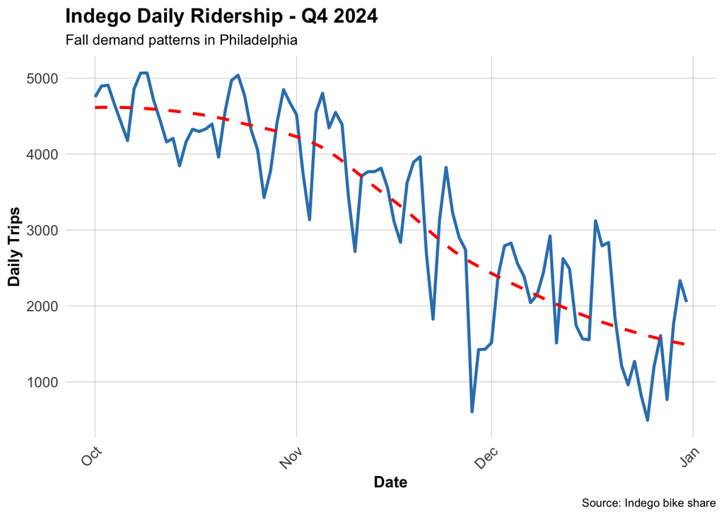

```r
# Daily trip counts
daily_trips <- indego %>%
  group_by(date) %>%
  summarize(trips = n())

ggplot(daily_trips, aes(x = date, y = trips)) +
  geom_line(color = "#3182bd", linewidth = 1) +
  geom_smooth(se = FALSE, color = "red", linetype = "dashed") +
  labs(
    title = "Indego Daily Ridership - Q4 2024",
    subtitle = "Fall demand patterns in Philadelphia",
    x = "Date",
    y = "Daily Trips",
    caption = "Source: Indego bike share"
  ) +
  plotTheme
```

**Ridership falls during autumn to winter transition.** There is also a particularly low ridership towards the end of November, perhaps November 28th, Thanksgiving 2024, as well as the end of December, likely December 25th, Christmas. We can confirm this intuition by examining those specific dates.

```r
turkey_day <- daily_trips %>% filter(date == "2024-11-28")
xmas <- daily_trips %>% filter(date == "2024-12-25")

typical_boring_thurs <- indego %>%
  filter(dotw == "Thu", date != "2024-11-28") %>%
  group_by(date) %>%
  summarize(trips = n()) %>%
  summarize(avg_thurs_trips = mean(trips))

typical_boring_wed <- indego %>%
  filter(dotw == "Wed", date != "2024-12-25") %>%
  group_by(date) %>%
  summarize(trips = n()) %>%
  summarize(avg_wed_trips = mean(trips))


print(turkey_day)
```

```
# A tibble: 1 × 2
  date       trips
  <date>     <int>
1 2024-11-28   604
```

```r
print(typical_boring_thurs)
```

```
# A tibble: 1 × 1
  avg_thurs_trips
            <dbl>
1           3634.
```

```r
print(xmas)
```

```
# A tibble: 1 × 2
  date       trips
  <date>     <int>
1 2024-12-25   495
```

```r
print(typical_boring_wed)
```

```
# A tibble: 1 × 1
  avg_wed_trips
          <dbl>
1         3845.
```

#### Hourly Patterns

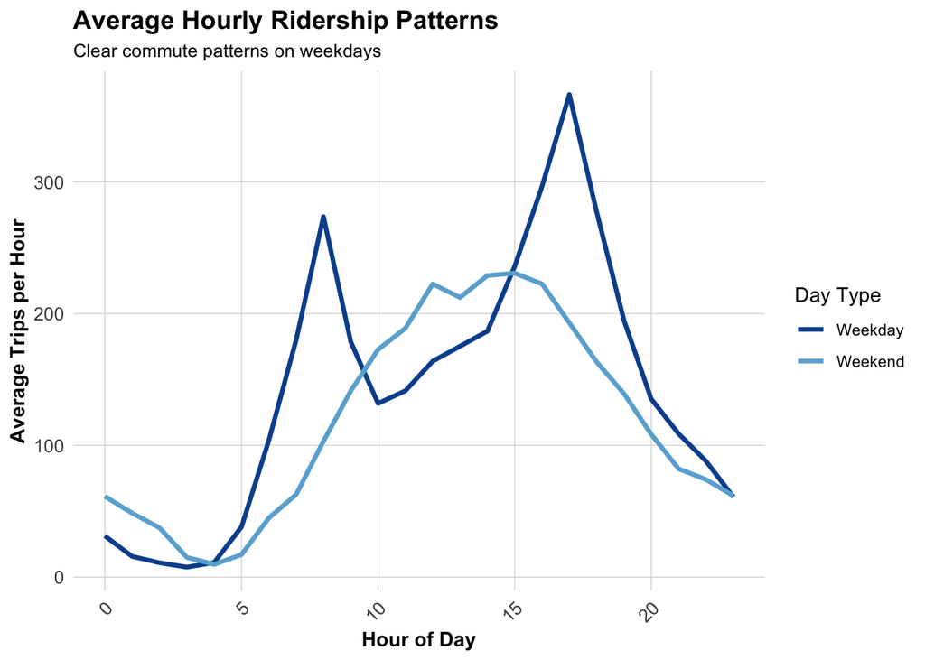

```r
# Average trips by hour and day type
hourly_patterns <- indego %>%
  group_by(hour, weekend) %>%
  summarize(avg_trips = n() / n_distinct(date)) %>%
  mutate(day_type = ifelse(weekend == 1, "Weekend", "Weekday"))

ggplot(hourly_patterns, aes(x = hour, y = avg_trips, color = day_type)) +
  geom_line(linewidth = 1.2) +
  scale_color_manual(values = c("Weekday" = "#08519c", "Weekend" = "#6baed6")) +
  labs(
    title = "Average Hourly Ridership Patterns",
    subtitle = "Clear commute patterns on weekdays",
    x = "Hour of Day",
    y = "Average Trips per Hour",
    color = "Day Type"
  ) +
  plotTheme
```

**Weekdays see two peaks during prime work commute hours,** whereas weekends see a smooth curve of average hourly trips throughout daylight hours, peaking around mid afternoon.

#### Top Stations

```r
# Most popular origin stations
top_stations <- indego %>%
  count(start_station, start_lat, start_lon, name = "trips") %>%
  arrange(desc(trips))

top_stations%>%head(20)%>%
kable(
      caption = "Top 20 Indego Stations by Trip Origins",
      format.args = list(big.mark = ",")) %>%
  kable_styling(bootstrap_options = c("striped", "hover"))
```

Top 20 Indego Stations by Trip Origins

| start_station | start_lat | start_lon | trips |
| --- | --- | --- | --- |
| 3,010 | 39.94711 | -75.16618 | 5,943 |
| 3,032 | 39.94527 | -75.17971 | 4,471 |
| 3,359 | 39.94888 | -75.16978 | 3,923 |
| 3,244 | 39.93865 | -75.16674 | 3,492 |
| 3,295 | 39.95028 | -75.16027 | 3,411 |
| 3,020 | 39.94855 | -75.19007 | 3,369 |
| 3,208 | 39.95048 | -75.19324 | 3,343 |
| 3,066 | 39.94561 | -75.17348 | 3,342 |
| 3,054 | 39.96250 | -75.17420 | 3,297 |
| 3,101 | 39.94295 | -75.15955 | 3,214 |
| 3,022 | 39.95472 | -75.18323 | 3,152 |
| 3,028 | 39.94061 | -75.14958 | 3,101 |
| 3,362 | 39.94816 | -75.16226 | 3,072 |
| 3,063 | 39.94633 | -75.16980 | 2,972 |
| 3,185 | 39.95169 | -75.15888 | 2,952 |
| 3,059 | 39.96244 | -75.16121 | 2,926 |
| 3,012 | 39.94218 | -75.17747 | 2,907 |
| 3,061 | 39.95425 | -75.17761 | 2,847 |
| 3,161 | 39.95486 | -75.18091 | 2,837 |
| 3,256 | 39.95269 | -75.17779 | 2,816 |

#### Load Philadelphia Census Data

#### Map Philadelphia Context

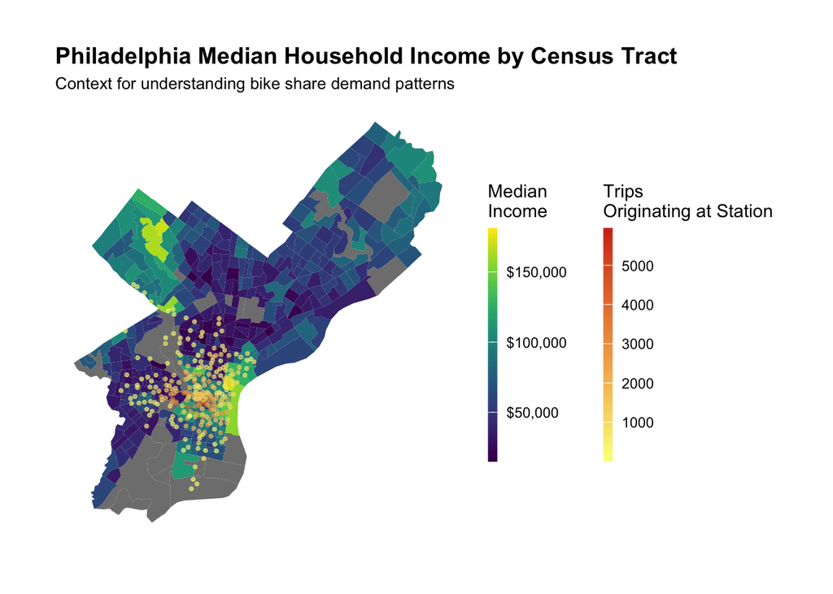

```r
# Map median income
ggplot() +
  geom_sf(data = philly_census, aes(fill = Med_Inc), color = NA) +
  scale_fill_viridis(
    option = "viridis",
    name = "Median\nIncome",
    labels = scales::dollar
  ) +
  labs(
    title = "Philadelphia Median Household Income by Census Tract",
    subtitle = "Context for understanding bike share demand patterns"
  ) +
  # Stations
  geom_point(
    data = top_stations,
    aes(x = start_lon, y = start_lat, color = trips),
    size = 0.75, alpha = 0.6
  ) +
  scale_color_gradientn(
    colours = c("#FAFF89", "#D3321D"),
    name = "Trips\nOriginating at Station"
  )  +
  guides(
    fill = guide_colorbar(),
    color = guide_colorbar()
  ) +
  theme(
    legend.position = "bottom",
    legend.box = "horizontal"     # <-- puts them side by side
  ) +
  mapTheme
```

#### Join Census Data to Stations

```r
# Create sf object for stations
stations_sf <- indego %>%
  distinct(start_station, start_lat, start_lon) %>%
  filter(!is.na(start_lat), !is.na(start_lon)) %>%
  st_as_sf(coords = c("start_lon", "start_lat"), crs = 4326)

# Spatial join to get census tract for each station
stations_census <- st_join(stations_sf, philly_census, left = TRUE) %>%
  st_drop_geometry()

# Look at the result - investigate whether all of the stations joined to census data -- according to the map above there are stations in non-residential tracts.

stations_for_map <- indego %>%
  distinct(start_station, start_lat, start_lon) %>%
  filter(!is.na(start_lat), !is.na(start_lon)) %>%
  left_join(
    stations_census %>% select(start_station, Med_Inc),
    by = "start_station"
  ) %>%
  mutate(has_census = !is.na(Med_Inc))

summary(stations_for_map$has_census)
```

```
   Mode   FALSE    TRUE
logical      19     237
```

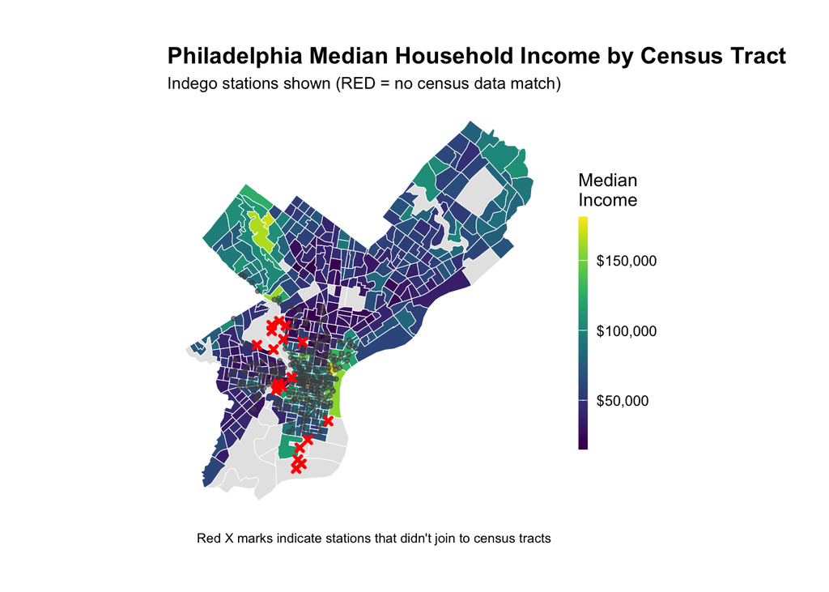

```r
# Add back to trip data
indego_census <- indego %>%
  left_join(
    stations_census %>%
      select(start_station, Med_Inc, Percent_Taking_Transit,
             Percent_White, Total_Pop),
    by = "start_station"
  )


# Prepare data for visualization
stations_for_map <- indego %>%
  distinct(start_station, start_lat, start_lon) %>%
  filter(!is.na(start_lat), !is.na(start_lon)) %>%
  left_join(
    stations_census %>% select(start_station, Med_Inc),
    by = "start_station"
  ) %>%
  mutate(has_census = !is.na(Med_Inc))

# Create the map showing problem stations
ggplot() +
  geom_sf(data = philly_census, aes(fill = Med_Inc), color = "white", size = 0.1) +
  scale_fill_viridis(
    option = "viridis",
    name = "Median\nIncome",
    labels = scales::dollar,
    na.value = "grey90"
  ) +
  # Stations with census data (small grey dots)
  geom_point(
    data = stations_for_map %>% filter(has_census),
    aes(x = start_lon, y = start_lat),
    color = "grey30", size = 1, alpha = 0.6
  ) +
  # Stations WITHOUT census data (red X marks the spot)
  geom_point(
    data = stations_for_map %>% filter(!has_census),
    aes(x = start_lon, y = start_lat),
    color = "red", size = 1, shape = 4, stroke = 1.5
  ) +
  labs(
    title = "Philadelphia Median Household Income by Census Tract",
    subtitle = "Indego stations shown (RED = no census data match)",
    caption = "Red X marks indicate stations that didn't join to census tracts"
  ) +
  mapTheme
```

```r
# Identify which stations to keep
valid_stations <- stations_census %>%
  filter(!is.na(Med_Inc)) %>%
  pull(start_station)

# Filter trip data to valid stations only
indego_census <- indego %>%
  filter(start_station %in% valid_stations) %>%
  left_join(
    stations_census %>%
      select(start_station, Med_Inc, Percent_Taking_Transit,
             Percent_White, Total_Pop),
    by = "start_station"
  )
```